# Modeling Lightning Strike Rate

# M6: Surface Pressure

Lightning strike rate modeled from a normal distribution where mu and sigma are dependant on climate: Surface Pressure

```
S ~ dnorm( mu , sigma ),
mu <- a_mu + b_mu * SP,
sigma <- a_sigma + b_sigma * SP,
```

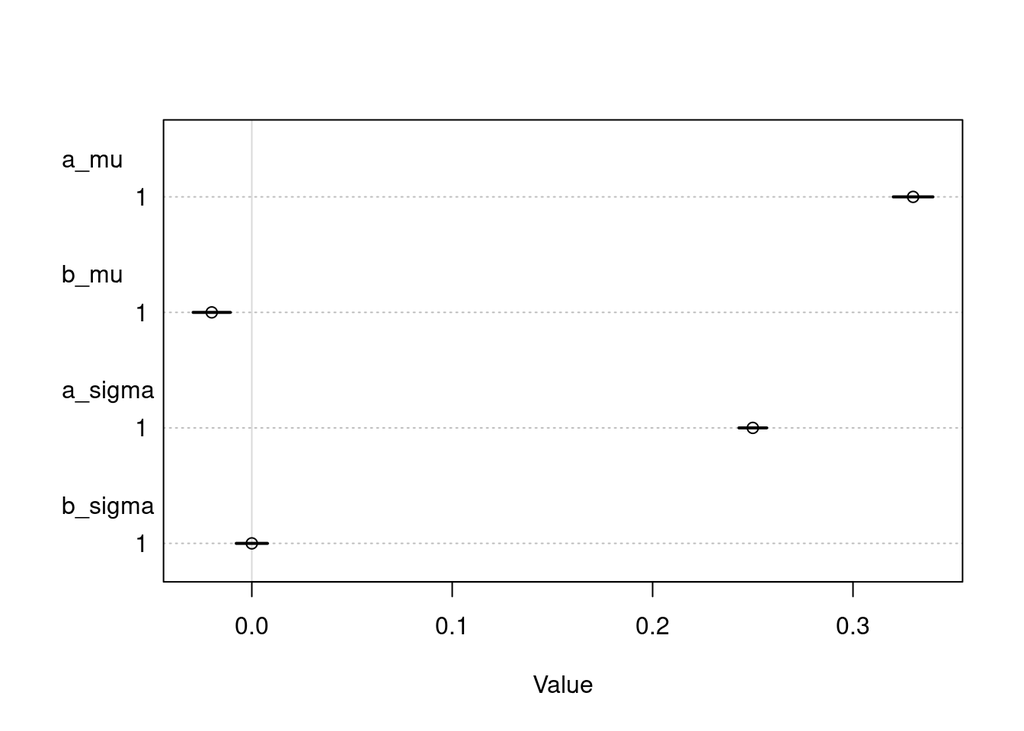

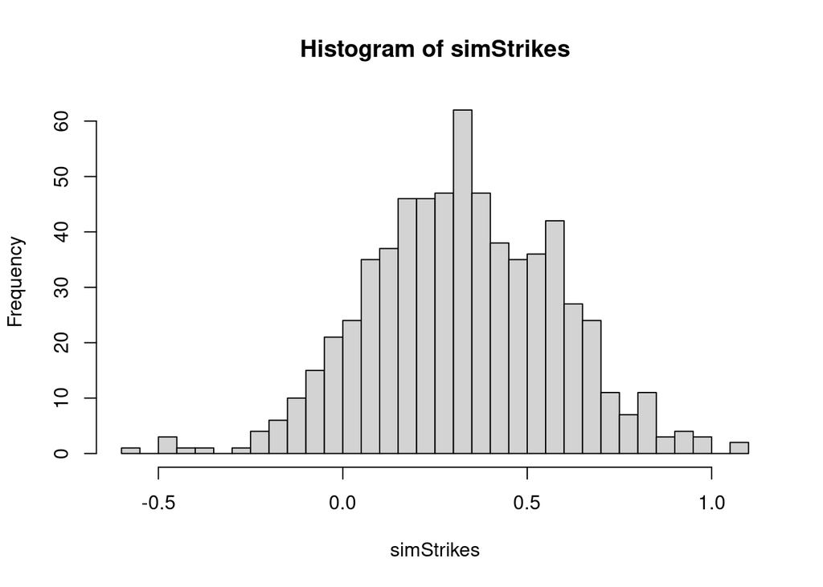

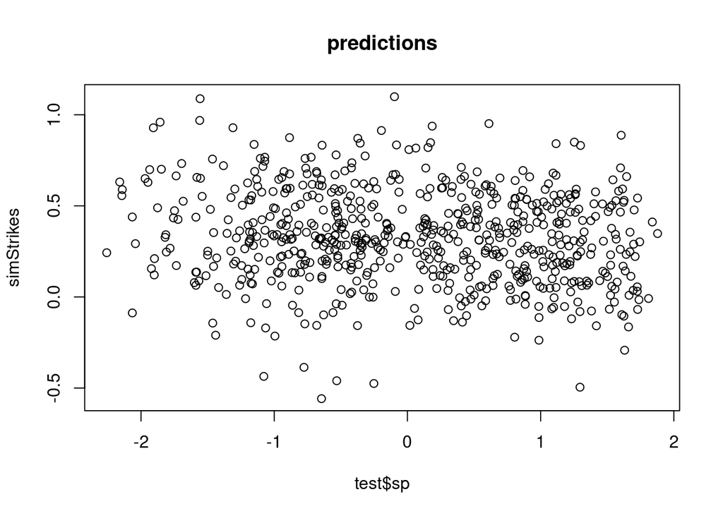

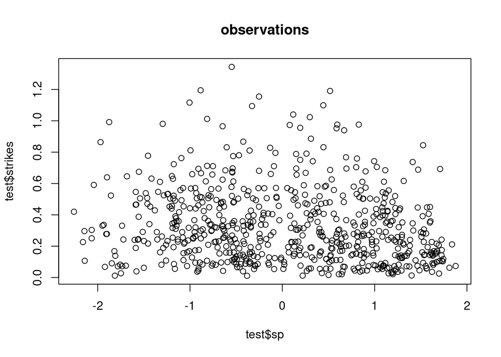

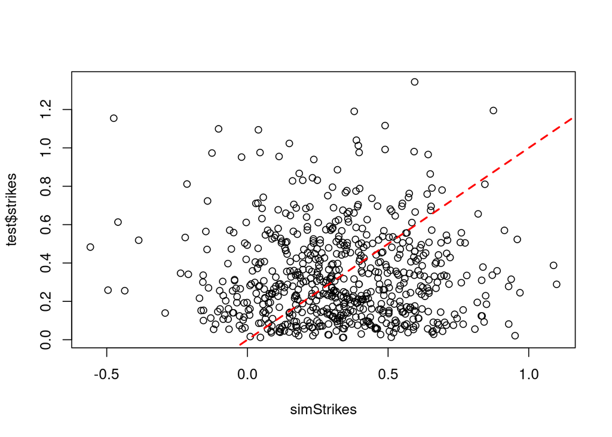

# M7: Precipitation

Lightning strike rate modeled from a normal distribution where mu and sigma are dependant on climate: Precipitation

```
S ~ dnorm( mu , sigma ),
mu <- a_mu + b_mu * P,
sigma <- a_sigma + b_sigma * P,
```

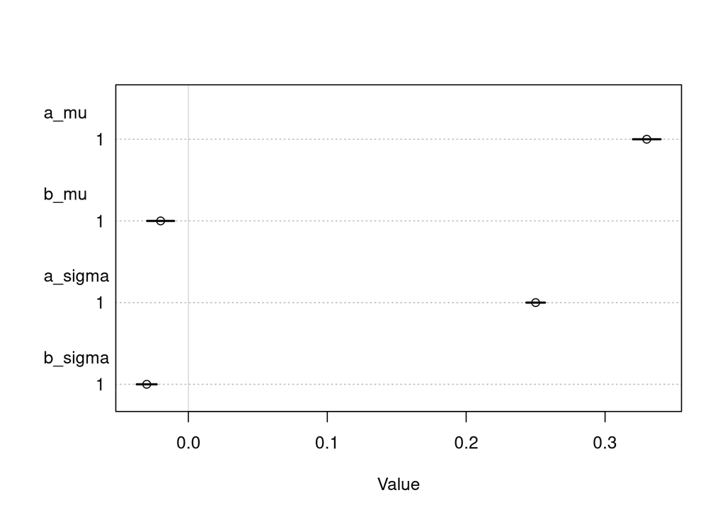

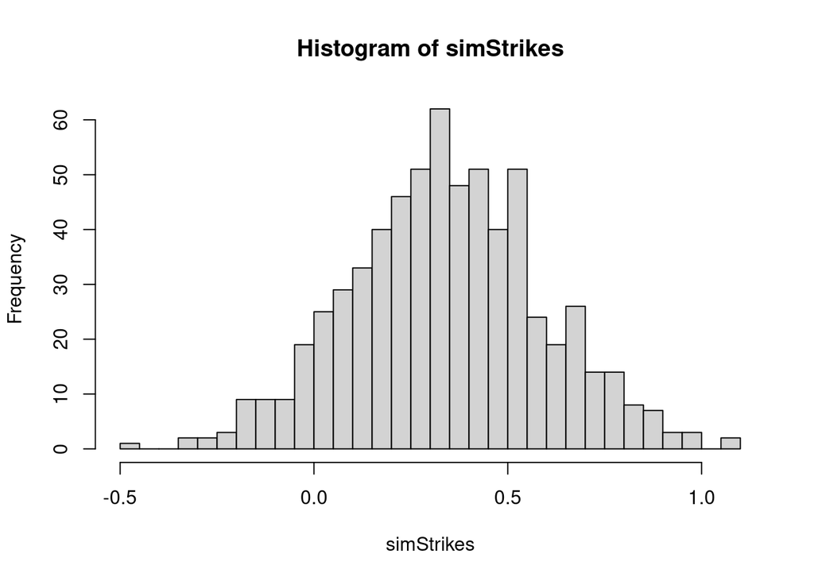

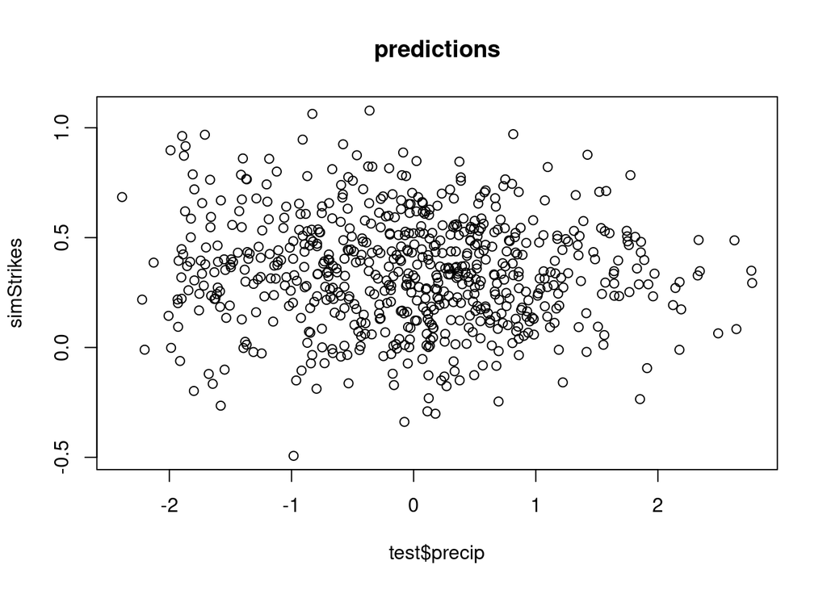

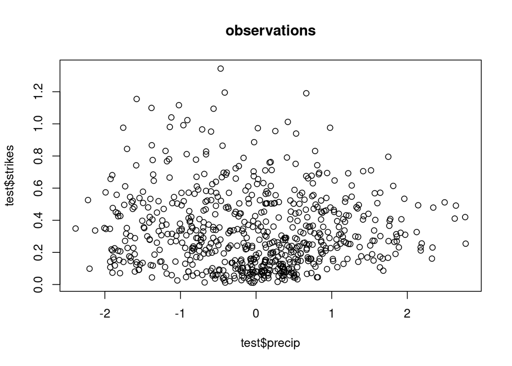

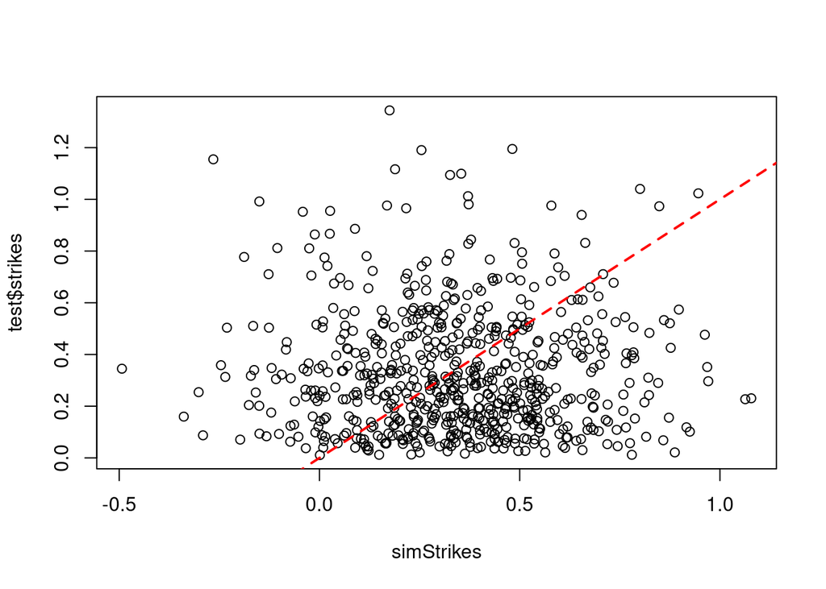

# M8: Wind

Lightning strike rate modeled from a normal distribution where mu and sigma are dependant on climate: Wind

```
S ~ dnorm( mu , sigma ),
mu <- a_mu + b_mu * W,
sigma <- a_sigma + b_sigma * W,
```

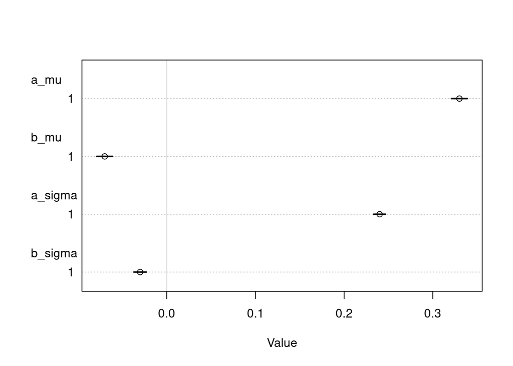

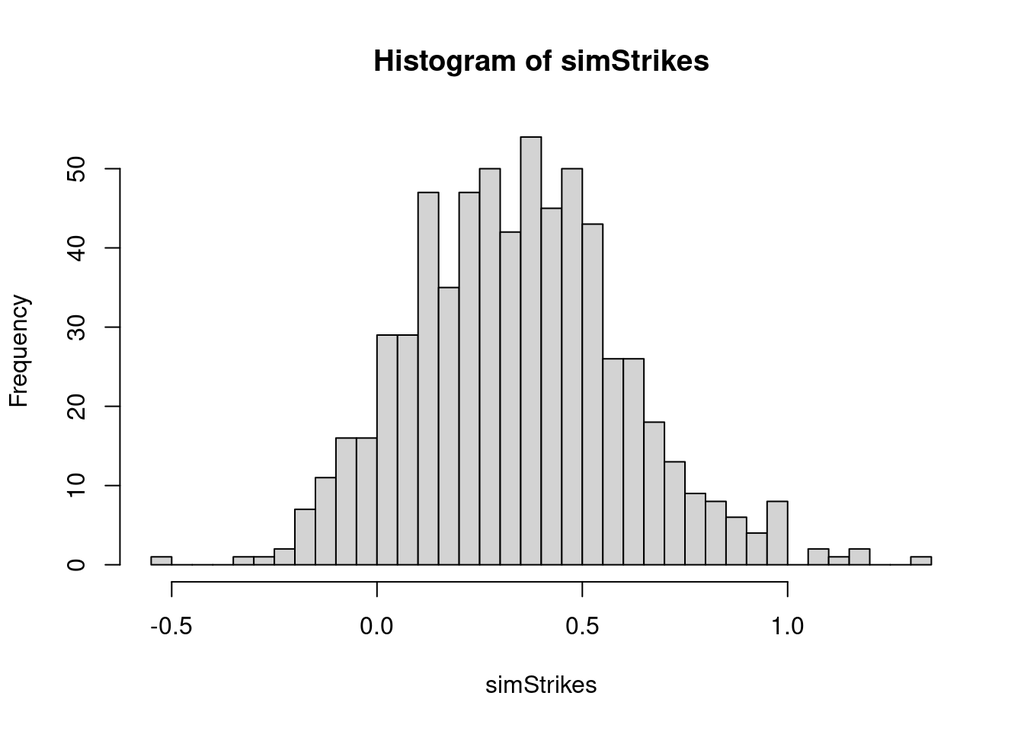

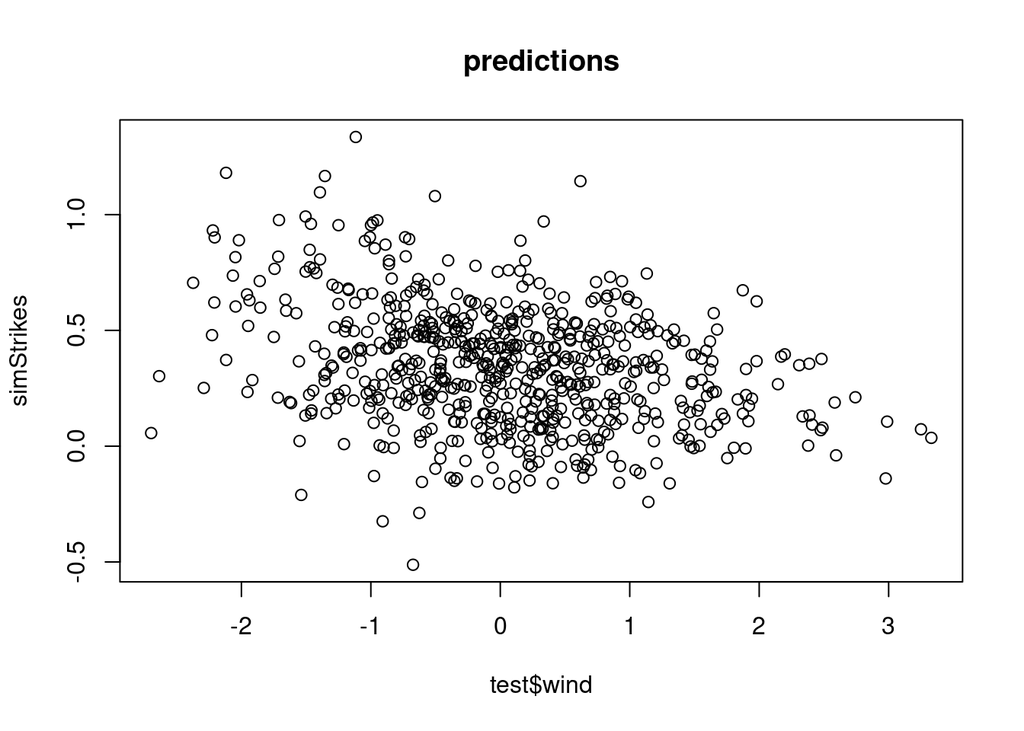

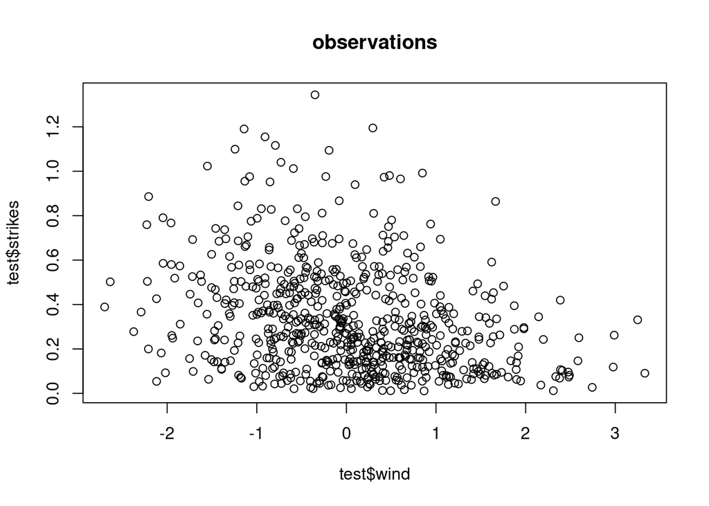

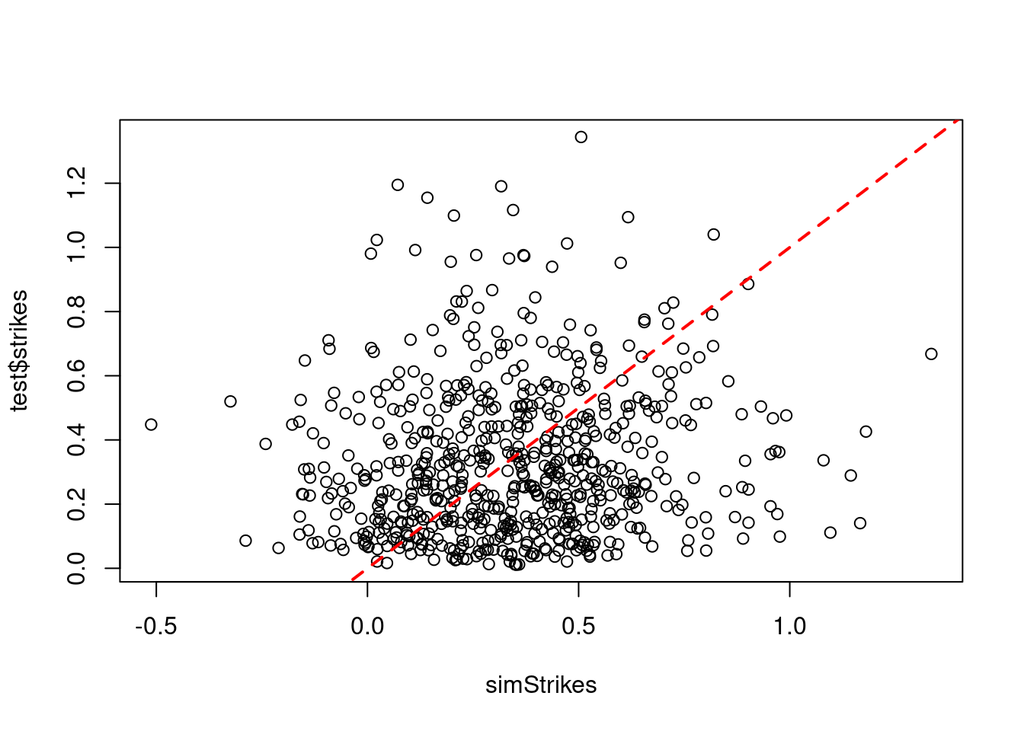

```
##          WAIC        SE     dWAIC       dSE    pWAIC        weight
## m1 -827.84453 141.91971    0.0000        NA 8.459330  1.000000e+00
## m4 -602.46681 101.81864  225.3777 116.80947 6.178981  1.147756e-49
## m5 -434.10114 116.67258  393.7434  92.11542 5.757263  3.160166e-86
## m2 -423.02011 141.21362  404.8244  74.67204 9.699963  1.240210e-88
## m3 -301.63451 105.78752  526.2100 126.05555 6.122462 5.431828e-115
## m8  -89.76577 114.80973  738.0788  98.48509 6.227969 5.348527e-161
## m7  134.42760  98.73916  962.2721 107.48190 5.588096 1.109845e-209
## m6  195.97247 103.46842 1023.8170  96.89781 6.142250 4.796944e-223
## m0  204.89512 102.89074 1032.7396  95.58238 2.995628 5.539056e-225
```

WAIC scores: best score is m1, CAPE. followed by shortwave radiation and temperature. (then CAPExPrecip, then relative humidity, wind, precip, surface pressure, and the null model). # M9: Short Wave Radiation + Temperature

Lightning strike rate modeled from a normal distribution where mu and sigma are dependant on climate: shortwave radiation and temperature, where swr and temp have addative affects. They contribute independently to the mean lightning strike rate and standard deviation. swr and temp do not intereact; ie. the effect of swr on lighting is teh same regardless of the temperature outside.

```
S ~ dnorm( mu , sigma ),
mu <- a_mu + b_mu * SWR + c_mu * T,
sigma <- a_sigma + b_sigma * SWR + c_sigma * T,
```

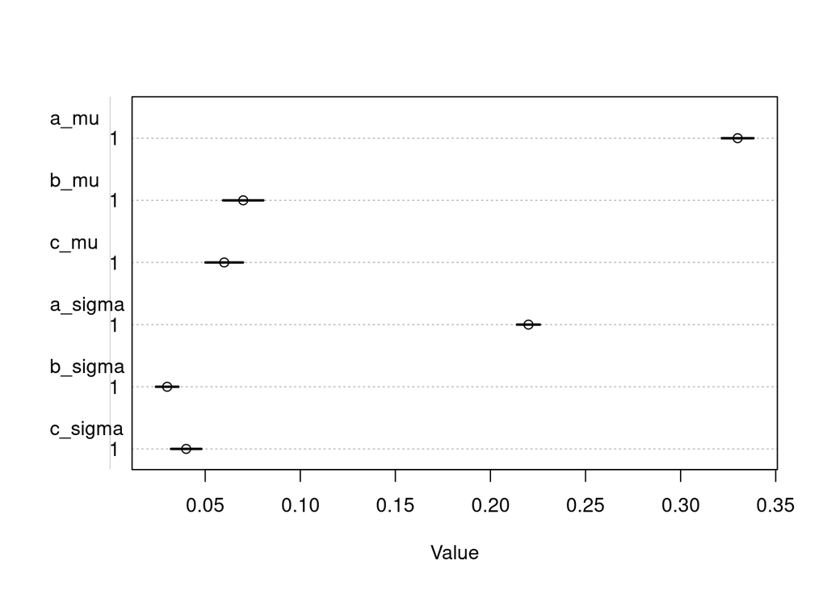

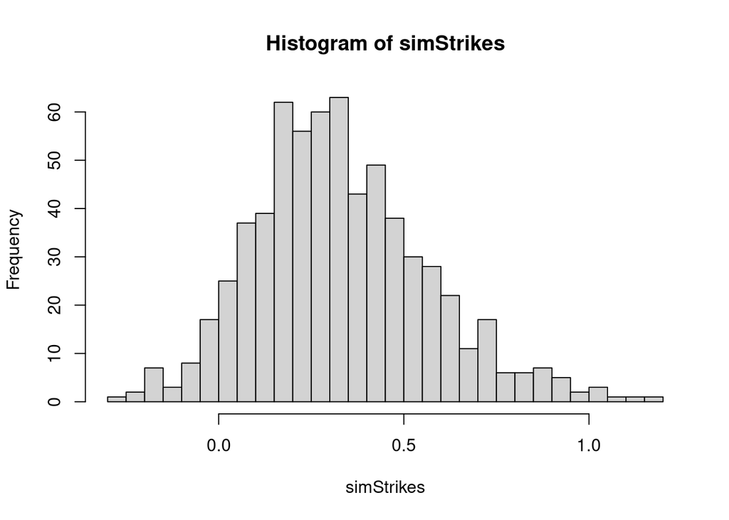

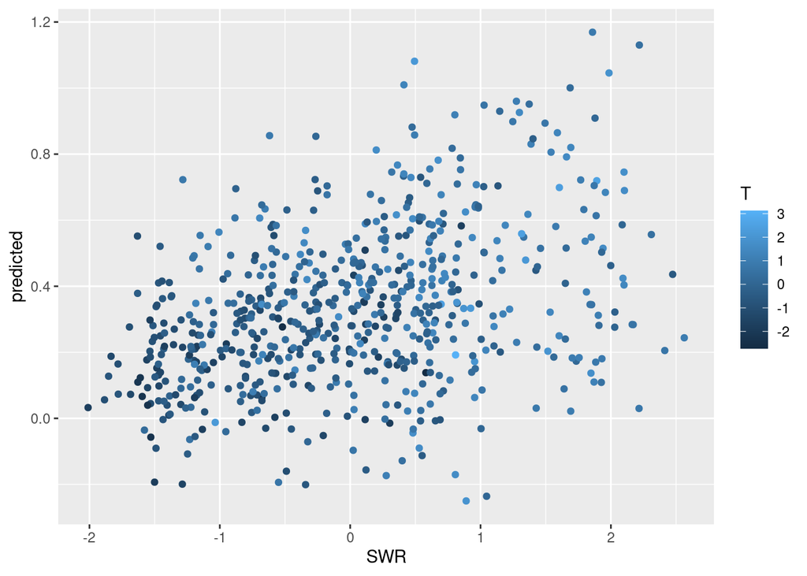

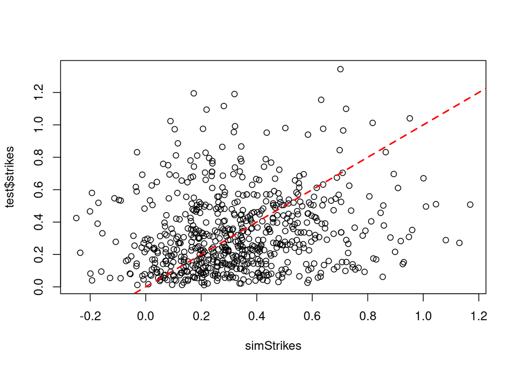

```
##          WAIC        SE       dWAIC       dSE    pWAIC        weight
## m9 -830.04659 111.46020    0.000000        NA 9.901245  7.504535e-01
## m1 -827.84453 141.91971    2.202065 112.69667 8.459330  2.495465e-01
## m4 -602.46681 101.81864  227.579786  48.08332 6.178981  2.864186e-50
## m5 -434.10114 116.67258  395.945452  55.69766 5.757263  7.886083e-87
## m2 -423.02011 141.21362  407.026481 113.96747 9.699963  3.094899e-89
## m3 -301.63451 105.78752  528.412085  71.64386 6.122462 1.355494e-115
## m8  -89.76577 114.80973  740.280823  82.61890 6.227969 1.334706e-161
## m7  134.42760  98.73916  964.474193  75.03104 5.588096 2.769579e-210
## m6  195.97247 103.46842 1026.019059  83.49021 6.142250 1.197060e-223
## m0  204.89512 102.89074 1034.941709  81.34489 2.995628 1.382252e-225
```

# M10: Short Wave Radiation x Temperature

Lightning strike rate modeled from a normal distribution where mu and sigma are dependent on climate: shortwave radiation and temperature, which interact. The independent effects of short wave radiation and temperature are not accounted for in this model.

```
S ~ dnorm( mu , sigma ),
mu <- a_mu + b_mu * SWR * T,
sigma <- a_sigma + b_sigma * SWR * T,
```

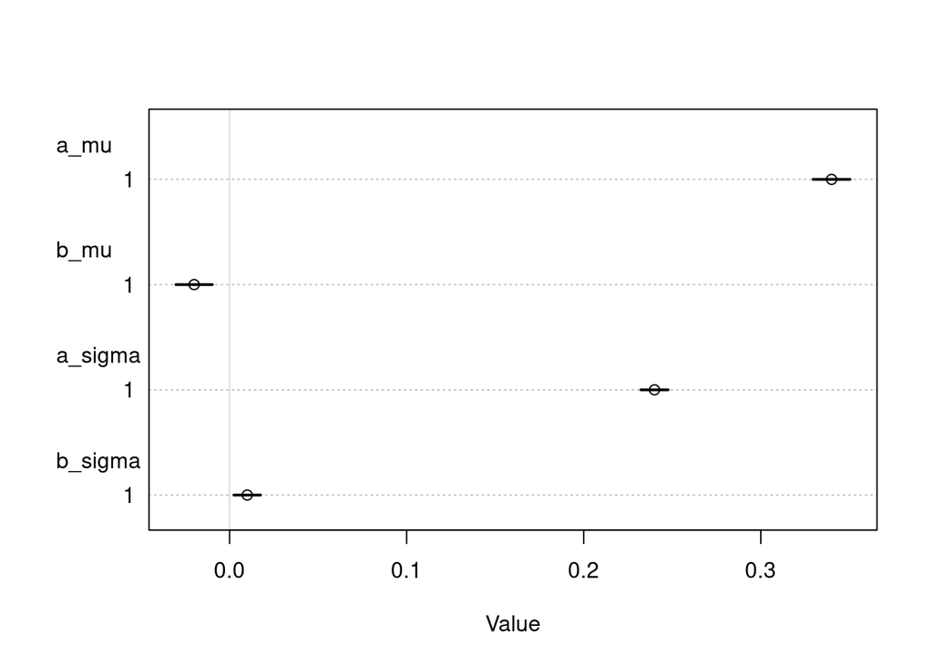

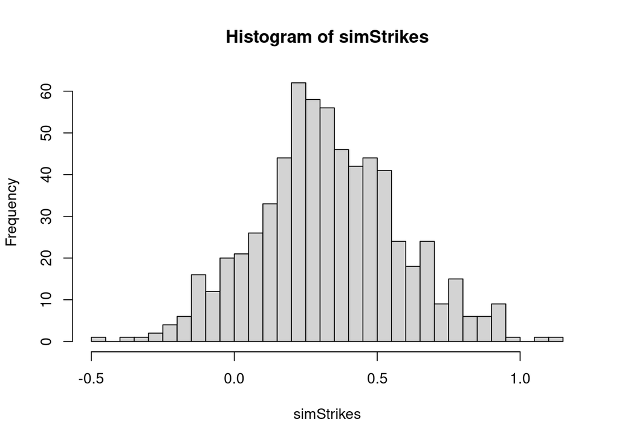

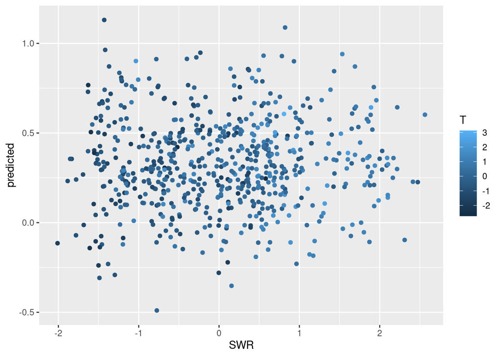

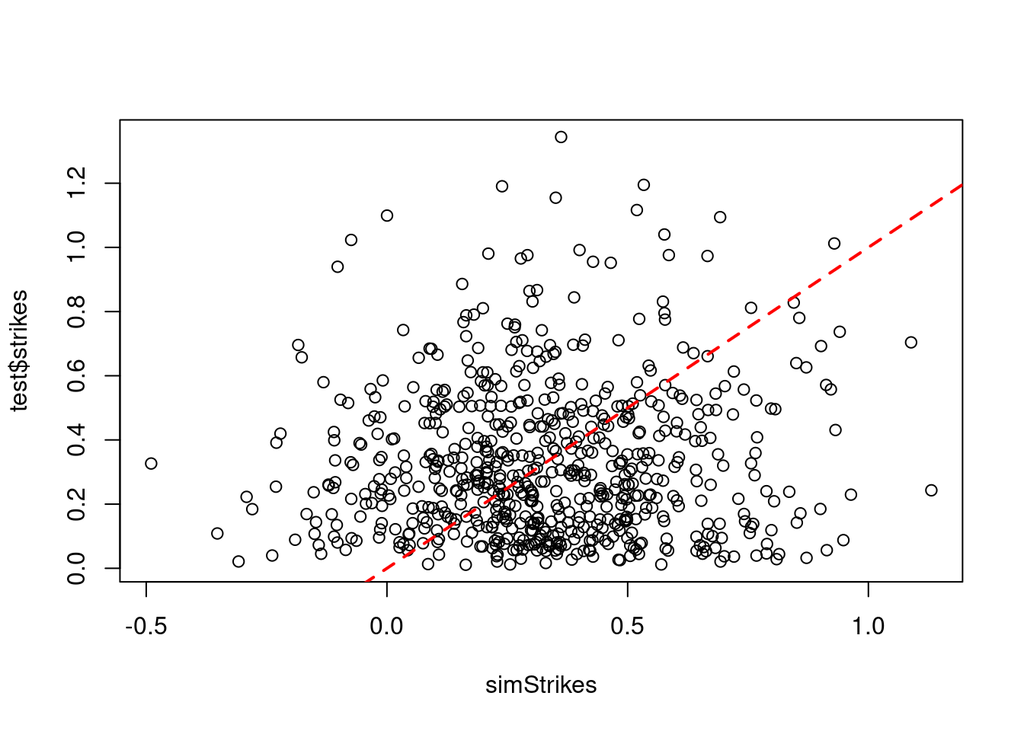

```
##           WAIC        SE       dWAIC       dSE    pWAIC        weight
## m9  -830.04659 111.46020    0.000000        NA 9.901245  7.504535e-01
## m1  -827.84453 141.91971    2.202065 112.69667 8.459330  2.495465e-01
## m4  -602.46681 101.81864  227.579786  48.08332 6.178981  2.864186e-50
## m5  -434.10114 116.67258  395.945452  55.69766 5.757263  7.886083e-87
## m2  -423.02011 141.21362  407.026481 113.96747 9.699963  3.094899e-89
## m3  -301.63451 105.78752  528.412085  71.64386 6.122462 1.355494e-115
## m8   -89.76577 114.80973  740.280823  82.61890 6.227969 1.334706e-161
## m7   134.42760  98.73916  964.474193  75.03104 5.588096 2.769579e-210
## m10  187.40496 104.53551 1017.451553  79.47715 5.539990 8.680133e-222
## m6   195.97247 103.46842 1026.019059  83.49021 6.142250 1.197060e-223
## m0   204.89512 102.89074 1034.941709  81.34489 2.995628 1.382252e-225
```

# M11: Short Wave Radiation + Temperature + (Short Wave Radiation x Temperature)

Lightning strike rate modeled from a normal distribution where mu and sigma are dependant on climate: shortwave radiation and temperature, where swr and temp have addative affects and an interaction term.

```
S ~ dnorm( mu , sigma ),
mu <- a_mu + b_mu*SWR + c_mu*T + d_mu*SWR*T,
sigma <- a_sigma + b_sigma*SWR + c_sigma*T + d_sigma*SWR*T,
```

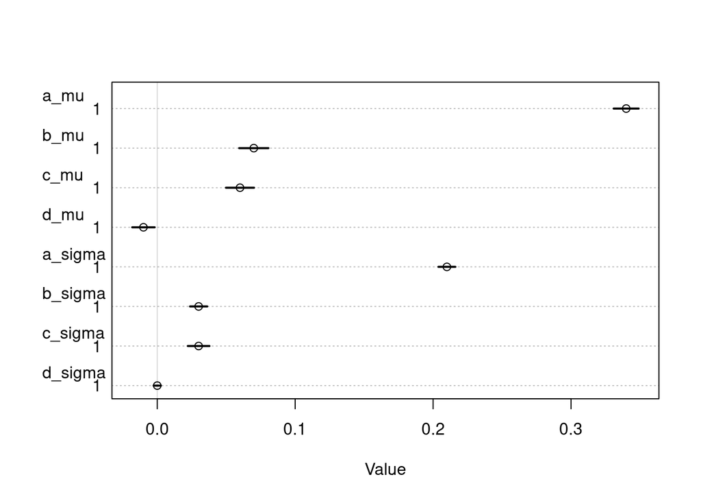

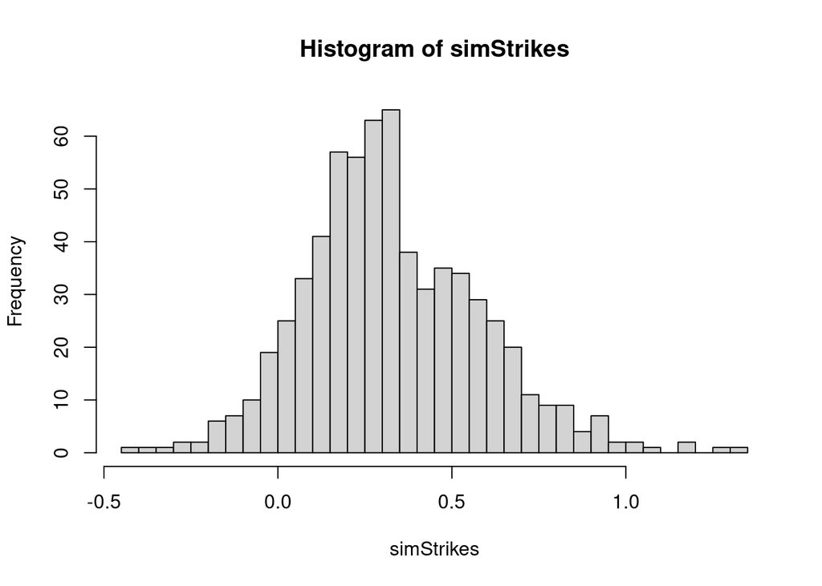

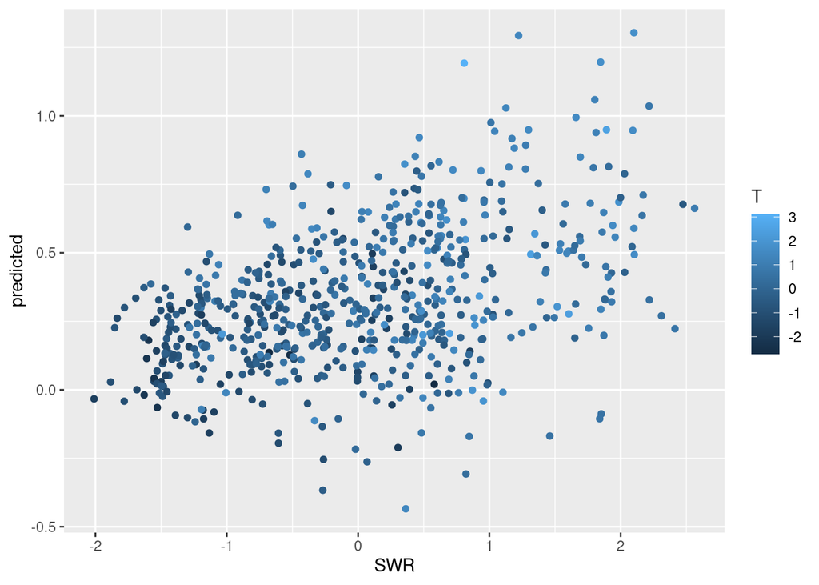

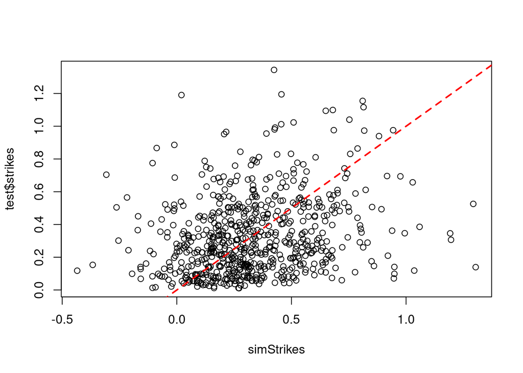

Note that d_sigma is very close to 0, which make the interaction term between swr and tair also almost 0 - so interactions between tair and swr are minimal. This means that m11 is essentially the same as m9. Add, in fact, has a similar WAIC score as m9.

```
##           WAIC        SE       dWAIC        dSE     pWAIC        weight
## m9  -830.04659 111.46020    0.000000         NA  9.901245  5.940935e-01
## m11 -827.95100 111.12105    2.095596   2.277898 11.140071  2.083540e-01
## m1  -827.84453 141.91971    2.202065 112.696674  8.459330  1.975525e-01
## m4  -602.46681 101.81864  227.579786  48.083322  6.178981  2.267421e-50
## m5  -434.10114 116.67258  395.945452  55.697659  5.757263  6.242986e-87
## m2  -423.02011 141.21362  407.026481 113.967467  9.699963  2.450064e-89
## m3  -301.63451 105.78752  528.412085  71.643864  6.122462 1.073071e-115
## m8   -89.76577 114.80973  740.280823  82.618899  6.227969 1.056615e-161
## m7   134.42760  98.73916  964.474193  75.031041  5.588096 2.192526e-210
## m10  187.40496 104.53551 1017.451553  79.477151  5.539990 6.871592e-222
## m6   195.97247 103.46842 1026.019059  83.490211  6.142250 9.476480e-224
## m0   204.89512 102.89074 1034.941709  81.344887  2.995628 1.094254e-225
```

# M12: Short Wave Radiation + Temperature + Relative Humidity

Lightning strike rate modeled from a normal distribution where mu and sigma are dependant on climate: shortwave radiation, temperature, and relative humidity, where each predictor variable has an additive affect, but do not interact. Relative humidity has been added since it has the next best WAIC score when comparing simpler models that predict lighting from just one climate variable.

```
S ~ dnorm( mu , sigma ),
mu <- a_mu + b_mu*SWR + c_mu*T + d_mu*RH,
sigma <- a_sigma + b_sigma*SWR + c_sigma*T + d_sigma*RH,
```

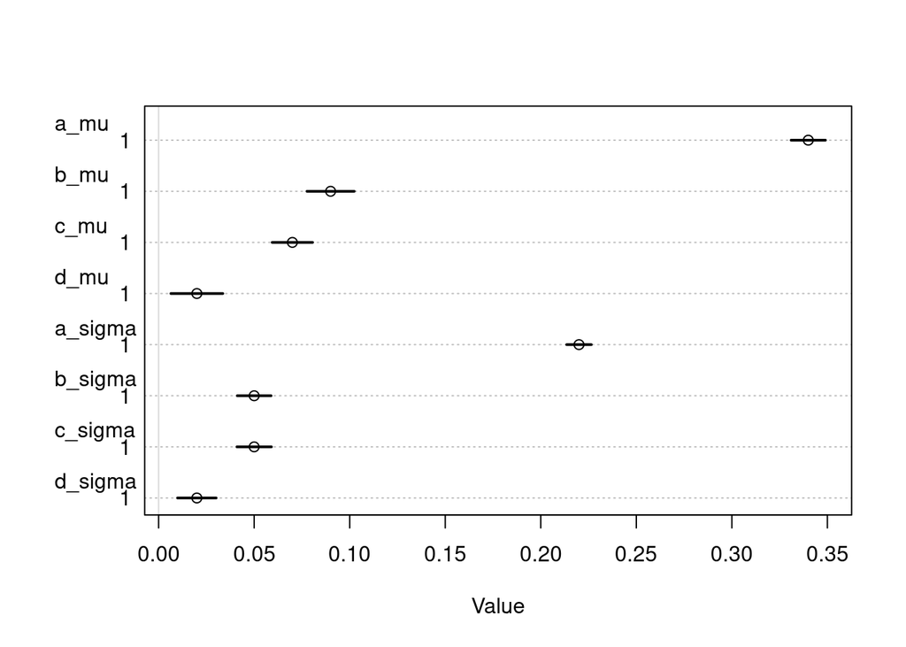

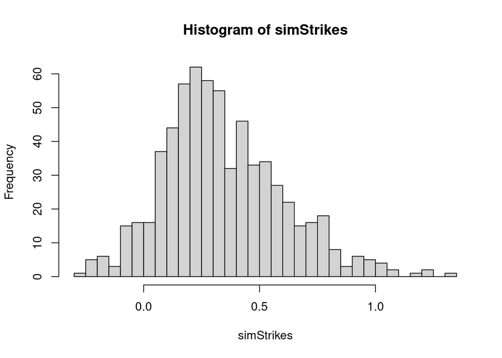

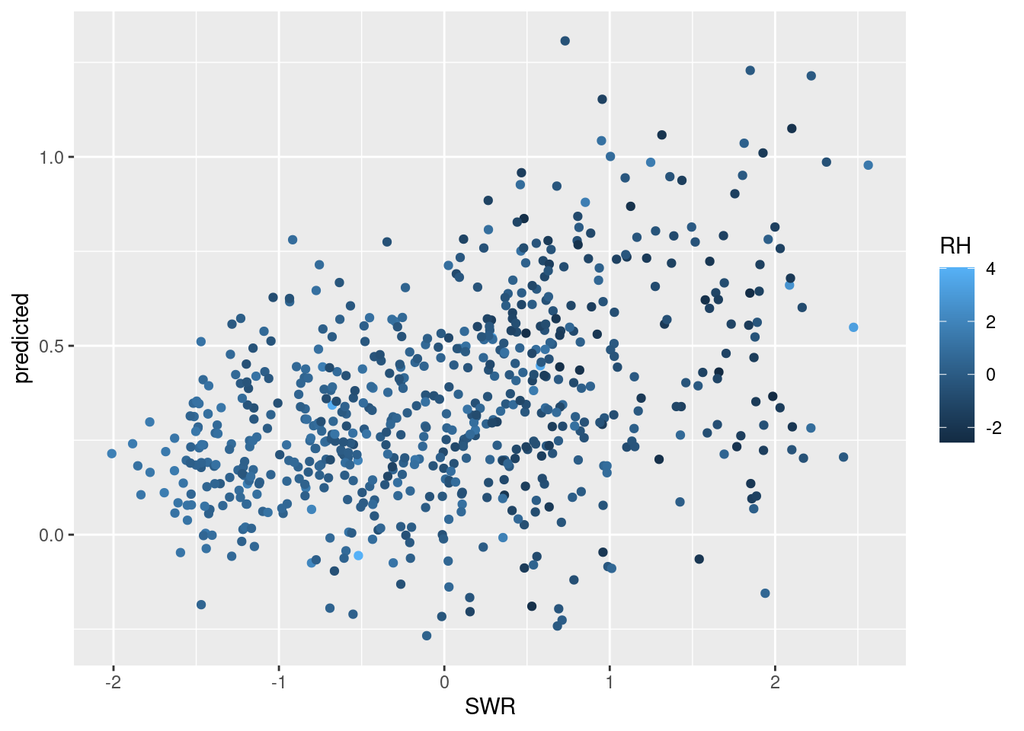

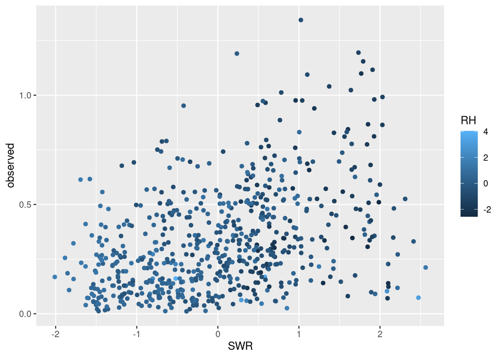

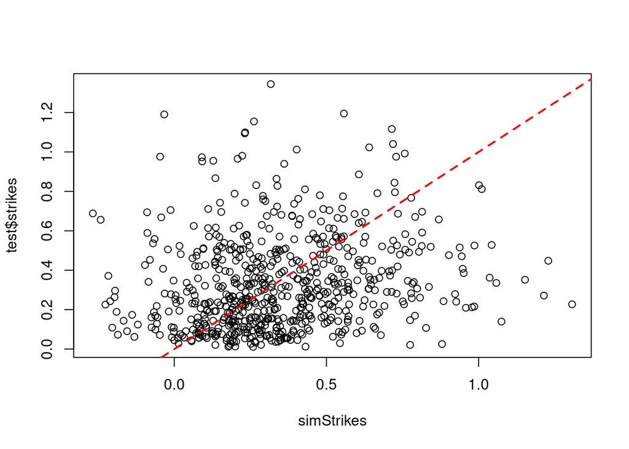

```
##           WAIC        SE      dWAIC       dSE     pWAIC        weight
## m12 -846.41240 114.38725    0.00000        NA 14.843355  9.995299e-01
## m9  -830.04659 111.46020   16.36581  18.48595  9.901245  2.792583e-04
## m11 -827.95100 111.12105   18.46140  18.72649 11.140071  9.793844e-05
## m1  -827.84453 141.91971   18.56787 107.80581  8.459330  9.286108e-05
## m4  -602.46681 101.81864  243.94559  52.51549  6.178981  1.065819e-53
## m5  -434.10114 116.67258  412.31126  59.32519  5.757263  2.934565e-90
## m2  -423.02011 141.21362  423.39229 111.28874  9.699963  1.151672e-92
## m3  -301.63451 105.78752  544.77789  82.31642  6.122462 5.044055e-119
## m8   -89.76577 114.80973  756.64663  86.03730  6.227969 4.966700e-165
## m7   134.42760  98.73916  980.84000  80.01270  5.588096 1.030614e-213
## m10  187.40496 104.53551 1033.81736  81.89494  5.539990 3.230046e-225
## m6   195.97247 103.46842 1042.38486  86.07383  6.142250 4.454494e-227
## m0   204.89512 102.89074 1051.30752  83.93455  2.995628 5.143627e-229
```

# M13: Short Wave Radiation + Temperature + Relative Humidity + Wind

Lightning strike rate modeled from a normal distribution where mu and sigma are dependent on climate: shortwave radiation, temperature, relative humidity, and wind, where each predictor variable has an additive affect, but do not interact. The wind model has the next best WAIC score.

```
S ~ dnorm( mu , sigma ),
mu <- a_mu + b_mu*SWR + c_mu*T + d_mu*RH + e_mu*W,
sigma <- a_sigma + b_sigma*SWR + c_sigma*T + d_sigma*RH +e_sigma*W,
```

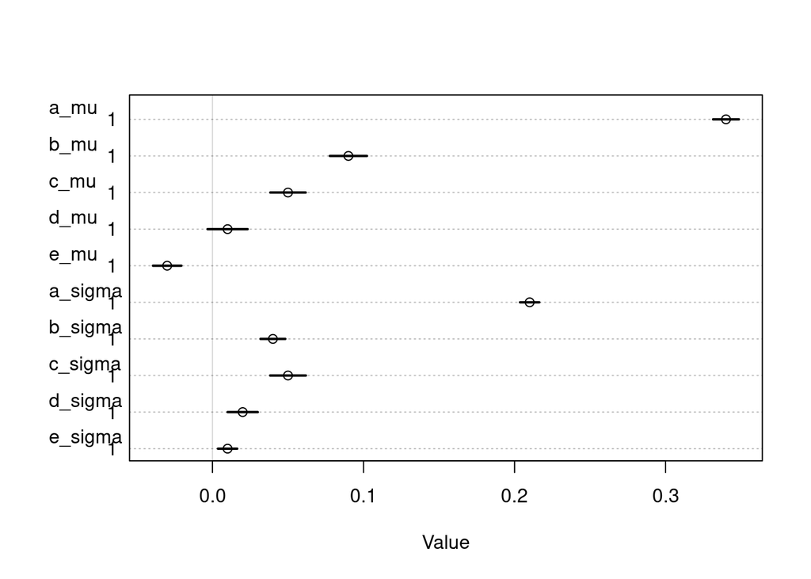

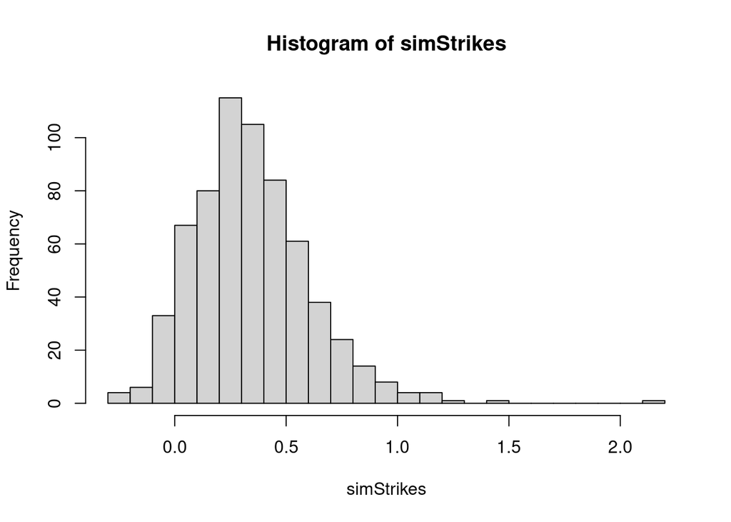

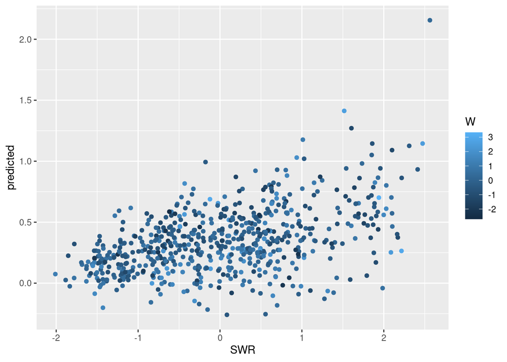

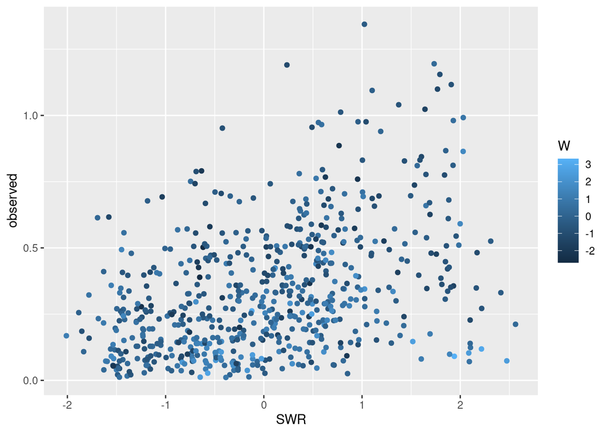

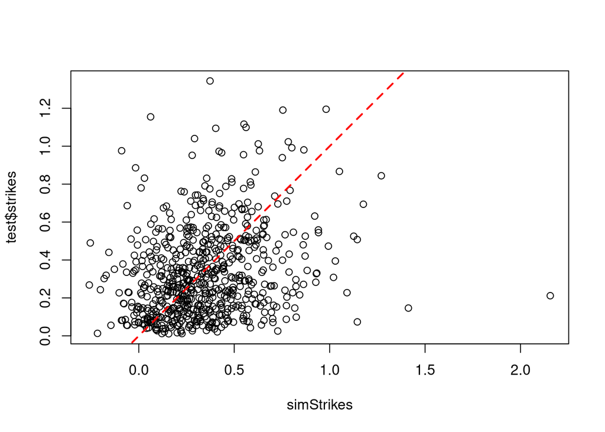

```
##           WAIC        SE      dWAIC       dSE     pWAIC        weight
## m13 -898.43999 114.39352    0.00000        NA 18.519880  1.000000e+00
## m12 -846.41240 114.38725   52.02760  12.08053 14.843355  5.039077e-12
## m9  -830.04659 111.46020   68.39340  19.86908  9.901245  1.407866e-15
## m11 -827.95100 111.12105   70.48900  19.73898 11.140071  4.937515e-16
## m1  -827.84453 141.91971   70.59547 106.59113  8.459330  4.681542e-16
## m4  -602.46681 101.81864  295.97319  50.26094  6.178981  5.373270e-65
## m5  -434.10114 116.67258  464.33885  58.31261  5.757263 1.479445e-101
## m2  -423.02011 141.21362  475.41988 109.43715  9.699963 5.806093e-104
## m3  -301.63451 105.78752  596.80549  80.31907  6.122462 2.542934e-130
## m8   -89.76577 114.80973  808.67423  82.55383  6.227969 2.503936e-176
## m7   134.42760  98.73916 1032.86760  77.95387  5.588096 5.195787e-225
## m10  187.40496 104.53551 1085.84496  79.78696  5.539990 1.628411e-236
## m6   195.97247 103.46842 1094.41246  84.16461  6.142250 2.245710e-238
## m0   204.89512 102.89074 1103.33511  81.97317  2.995628 2.593132e-240
```

# M14: Short Wave Radiation + Temperature + Relative Humidity + Wind + Precipitation

Lightning strike rate modeled from a normal distribution where mu and sigma are dependent on climate: shortwave radiation, temperature, relative humidity, wind, and precipitation, where each predictor variable has an additive affect, but do not interact. The precipitation model has the next best WAIC score.

```
S ~ dnorm( mu , sigma ),
mu <- a_mu + b_mu*SWR + c_mu*T + d_mu*RH + e_mu*W + f_mu*P,
sigma <- a_sigma + b_sigma*SWR + c_sigma*T + d_sigma*RH + e_sigma*W + f_sigma*P,
```

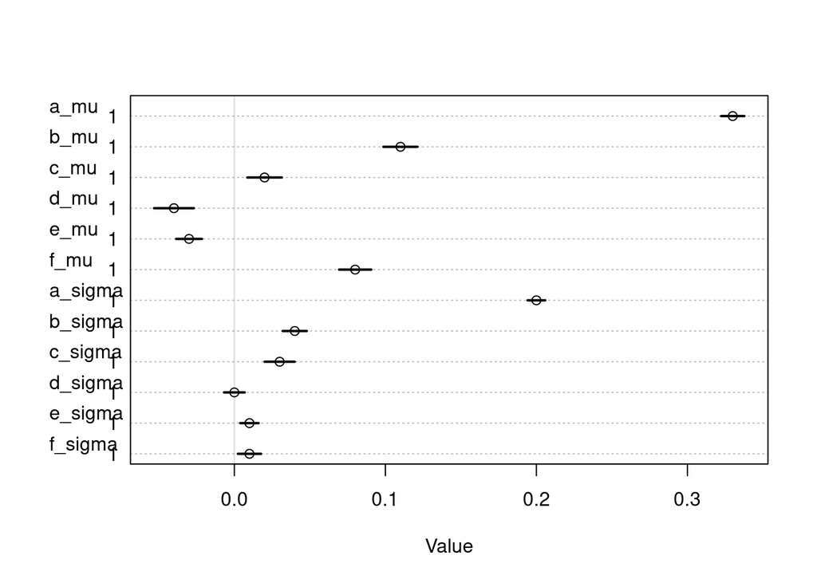

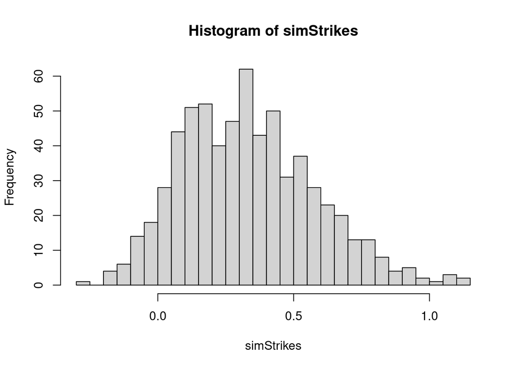

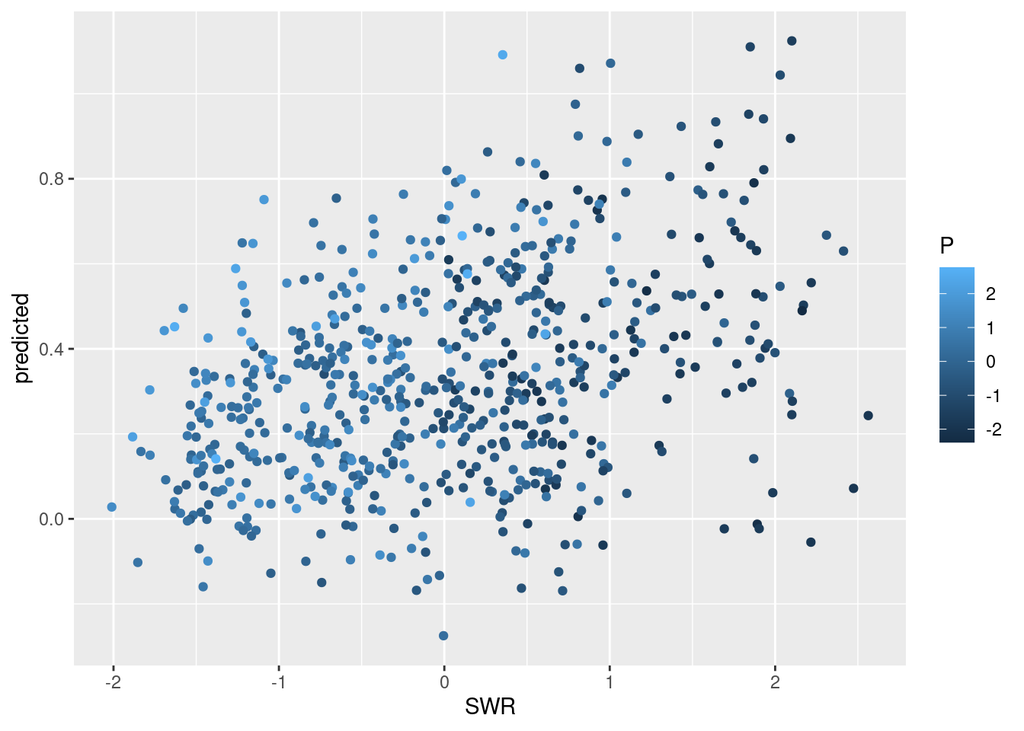

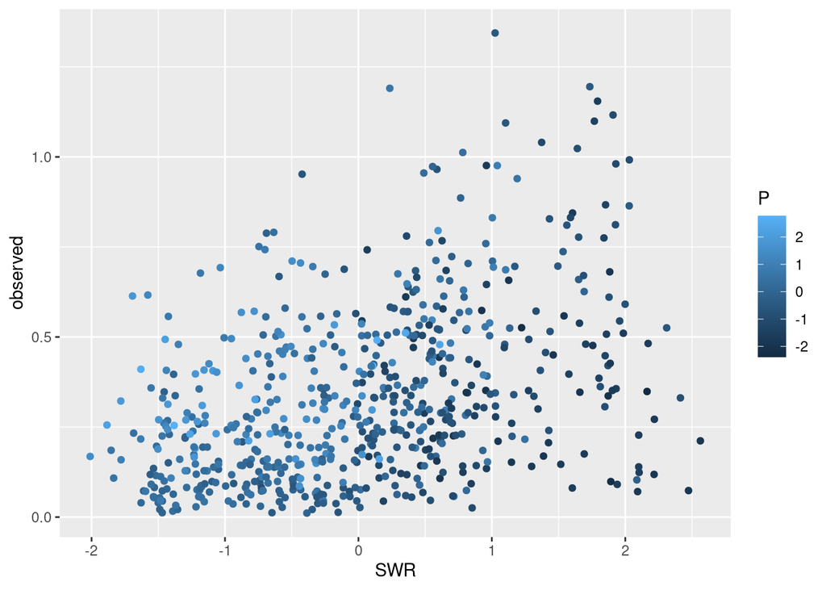

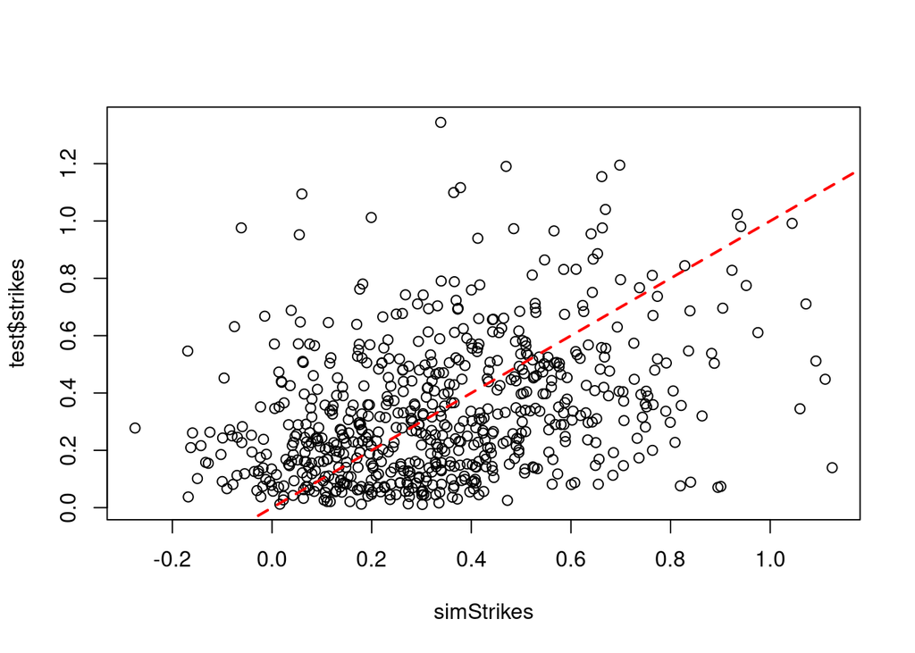

```
##            WAIC        SE     dWAIC       dSE     pWAIC        weight
## m14 -1112.13442 119.91578    0.0000        NA 20.357696  1.000000e+00
## m13  -898.43999 114.39352  213.6944  34.40985 18.519880  3.952256e-47
## m12  -846.41240 114.38725  265.7220  36.75387 14.843355  1.991573e-58
## m9   -830.04659 111.46020  282.0878  38.39422  9.901245  5.564247e-62
## m11  -827.95100 111.12105  284.1834  38.17115 11.140071  1.951432e-62
## m1   -827.84453 141.91971  284.2899 105.76613  8.459330  1.850266e-62
## m4   -602.46681 101.81864  509.6676  60.07418  6.178981 2.123654e-111
## m5   -434.10114 116.67258  678.0333  67.04350  5.757263 5.847147e-148
## m2   -423.02011 141.21362  689.1143 101.26551  9.699963 2.294717e-150
## m3   -301.63451 105.78752  810.4999  82.81915  6.122462 1.005033e-176
## m8    -89.76577 114.80973 1022.3687  84.20090  6.227969 9.896195e-223
## m7    134.42760  98.73916 1246.5620  84.95897  5.588096 2.053508e-271
## m10   187.40496 104.53551 1299.5394  81.85269  5.539990 6.435896e-283
## m6    195.97247 103.46842 1308.1069  85.34146  6.142250 8.875620e-285
## m0    204.89512 102.89074 1317.0295  83.81385  2.995628 1.024872e-286
```

# M15: Short Wave Radiation + Temperature + Relative Humidity + Wind + Precipitation + Surface Pressure

Lightning strike rate modeled from a normal distribution where mu and sigma are dependent on climate: shortwave radiation, temperature, relative humidity, wind, precipitation, and surface pressure, where each predictor variable has an additive affect, but do not interact. The surface pressure model has the next best WAIC score, but also the lowest after the null model, so it may not improve predictions by much.

```
S ~ dnorm( mu , sigma ),
mu <- a_mu + b_mu*SWR + c_mu*T + d_mu*RH + e_mu*W + f_mu*P + g_mu*SP,
sigma <- a_sigma + b_sigma*SWR + c_sigma*T + d_sigma*RH + e_sigma*W + f_sigma*P + g_sigma*SP,
```

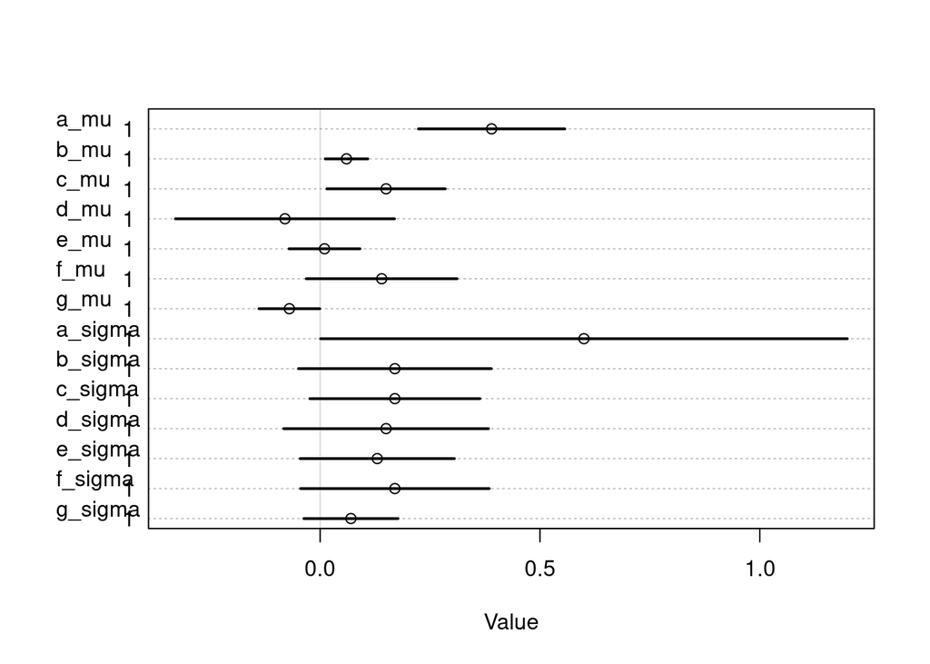

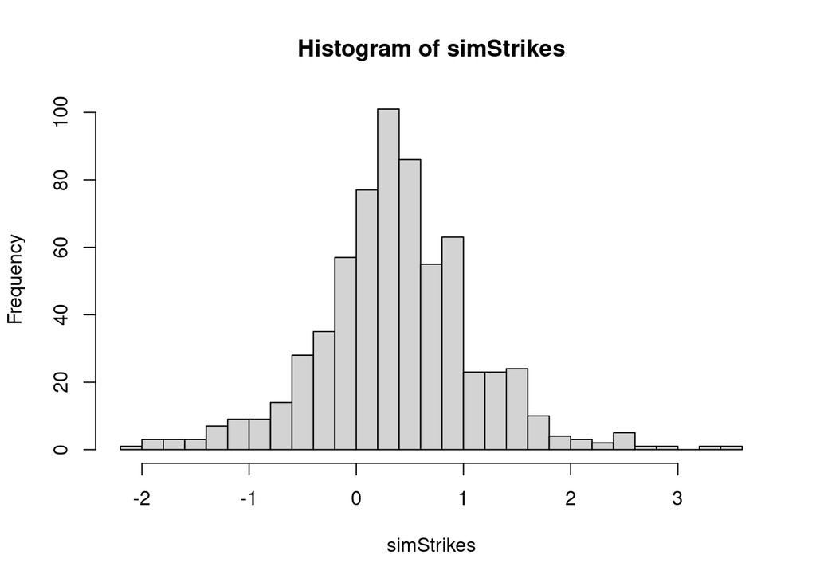

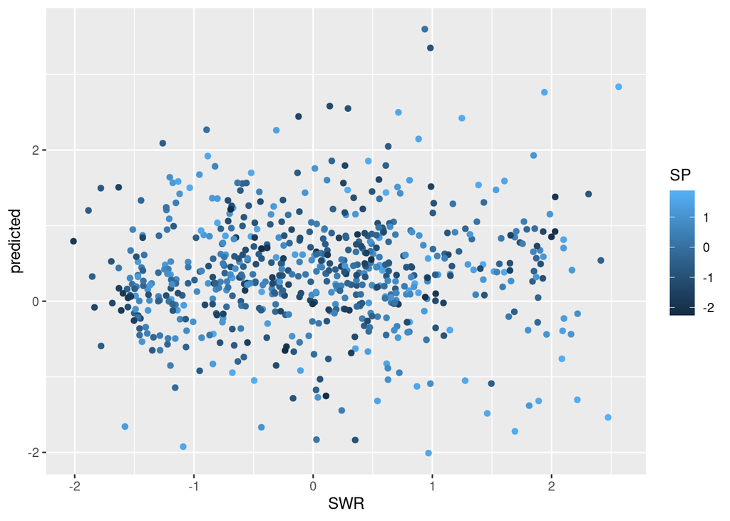

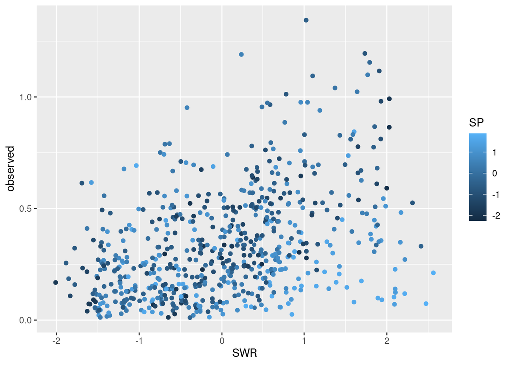

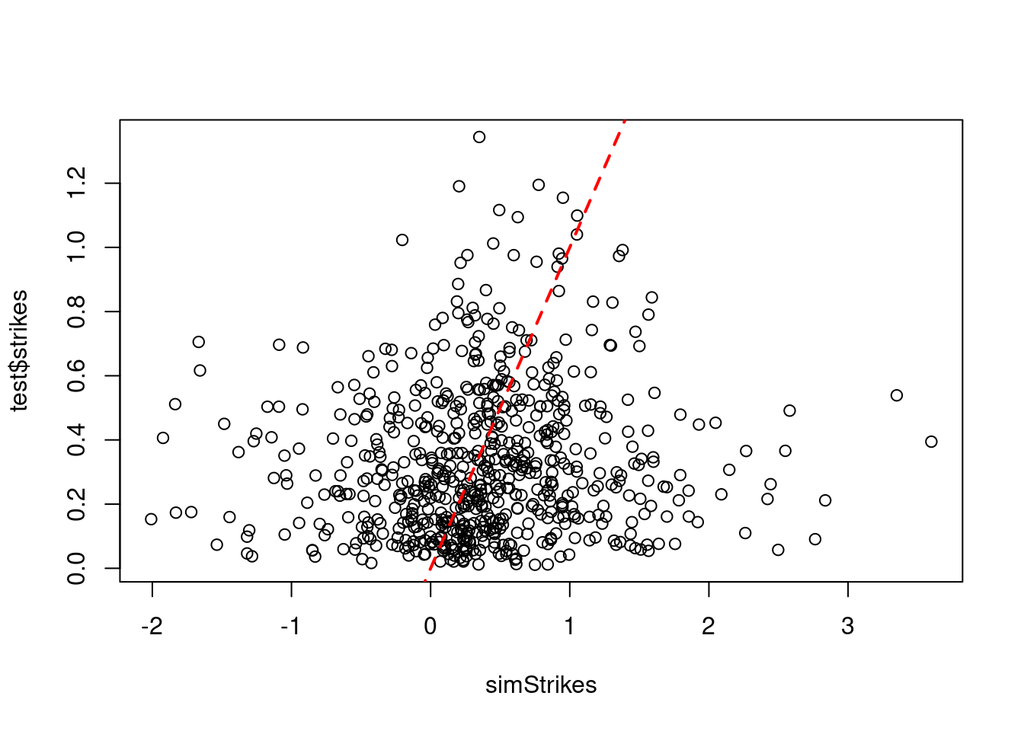

```
##            WAIC        SE     dWAIC       dSE       pWAIC        weight
## m14 -1112.13442 119.91578    0.0000        NA   20.357696  1.000000e+00
## m13  -898.43999 114.39352  213.6944  34.40985   18.519880  3.952256e-47
## m12  -846.41240 114.38725  265.7220  36.75387   14.843355  1.991573e-58
## m9   -830.04659 111.46020  282.0878  38.39422    9.901245  5.564247e-62
## m11  -827.95100 111.12105  284.1834  38.17115   11.140071  1.951432e-62
## m1   -827.84453 141.91971  284.2899 105.76613    8.459330  1.850266e-62
## m4   -602.46681 101.81864  509.6676  60.07418    6.178981 2.123654e-111
## m5   -434.10114 116.67258  678.0333  67.04350    5.757263 5.847147e-148
## m2   -423.02011 141.21362  689.1143 101.26551    9.699963 2.294717e-150
## m3   -301.63451 105.78752  810.4999  82.81915    6.122462 1.005033e-176
## m8    -89.76577 114.80973 1022.3687  84.20090    6.227969 9.896195e-223
## m7    134.42760  98.73916 1246.5620  84.95897    5.588096 2.053508e-271
## m10   187.40496 104.53551 1299.5394  81.85269    5.539990 6.435896e-283
## m6    195.97247 103.46842 1308.1069  85.34146    6.142250 8.875620e-285
## m0    204.89512 102.89074 1317.0295  83.81385    2.995628 1.024872e-286
## m15  3608.82534 249.99219 4720.9598 184.81117 1427.333891  0.000000e+00
```

# M16: Short Wave Radiation + Temperature + Relative Humidity + Precipitation + Surface Pressure

```
S ~ dnorm( mu , sigma ),
mu <- a_mu + b_mu*SWR + c_mu*T + d_mu*RH + f_mu*P + g_mu*SP,
sigma <- a_sigma + b_sigma*SWR + c_sigma*T + d_sigma*RH + f_sigma*P + g_sigma*SP,
```

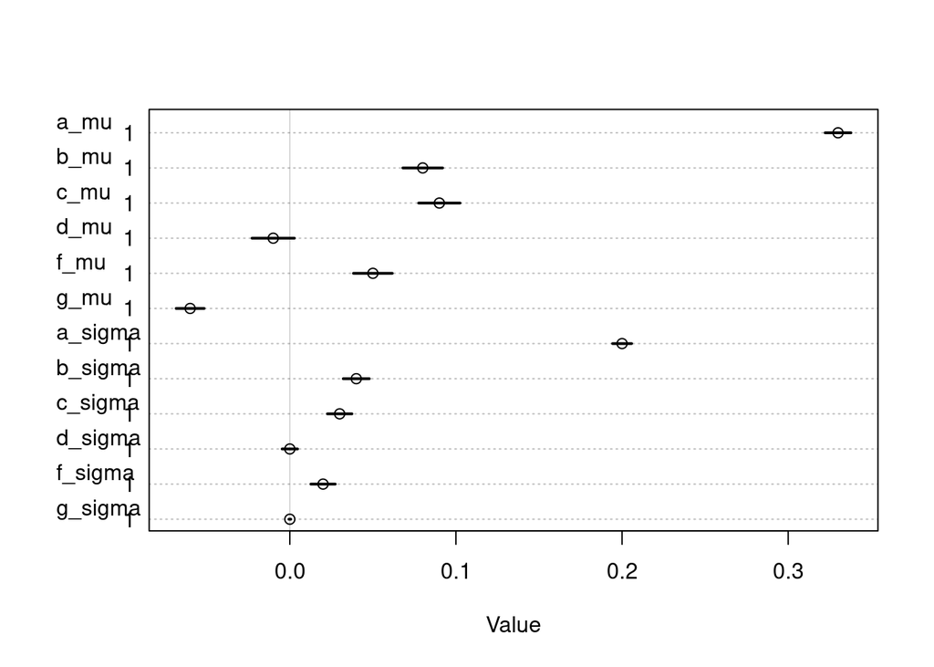

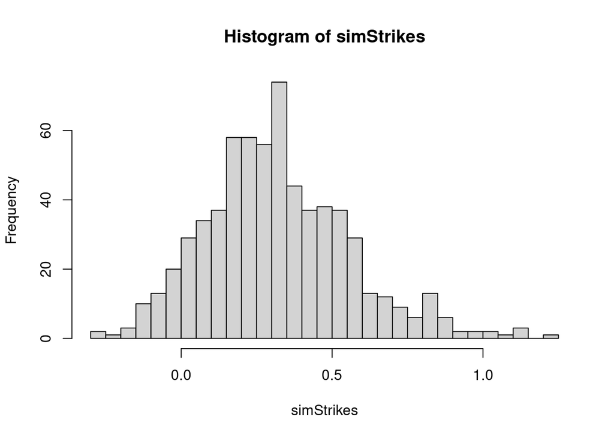

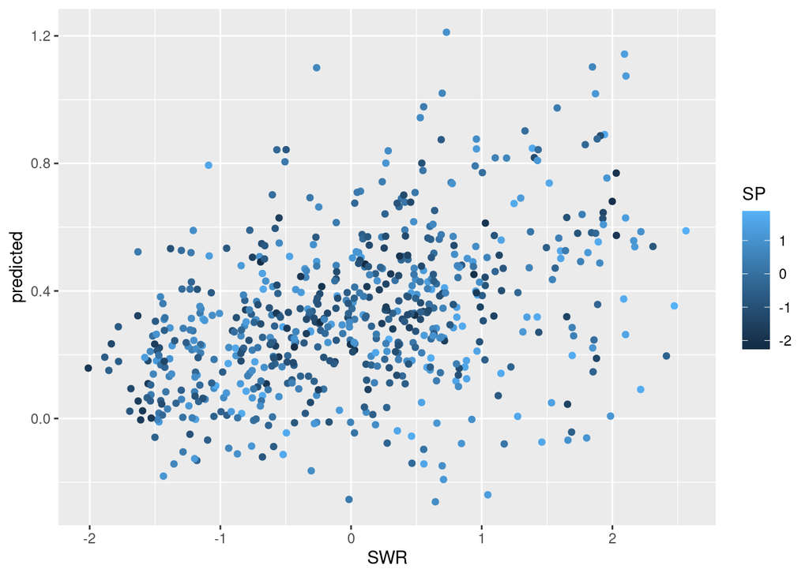

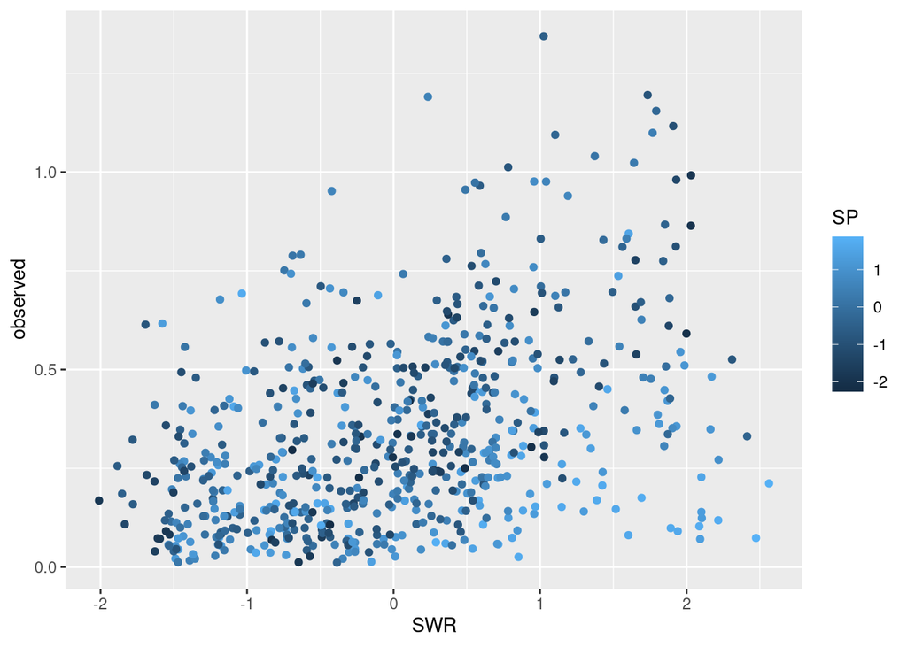

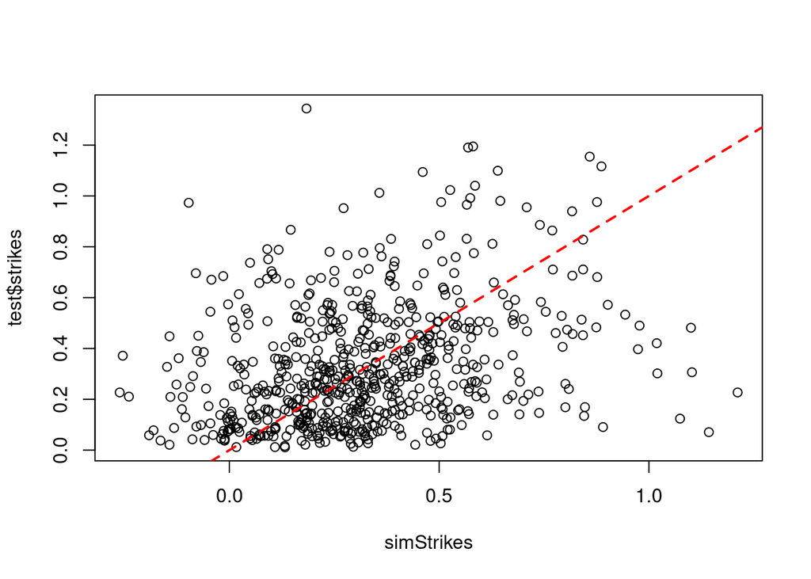

# M17: Short Wave Radiation + Temperature + Relative Humidity + Precipitation

```
S ~ dnorm( mu , sigma ),
mu <- a_mu + b_mu*SWR + c_mu*T + d_mu*RH + f_mu*P,
sigma <- a_sigma + b_sigma*SWR + c_sigma*T + d_sigma*RH + f_sigma*P,
```

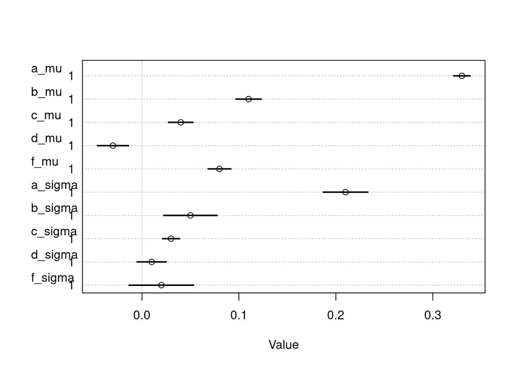

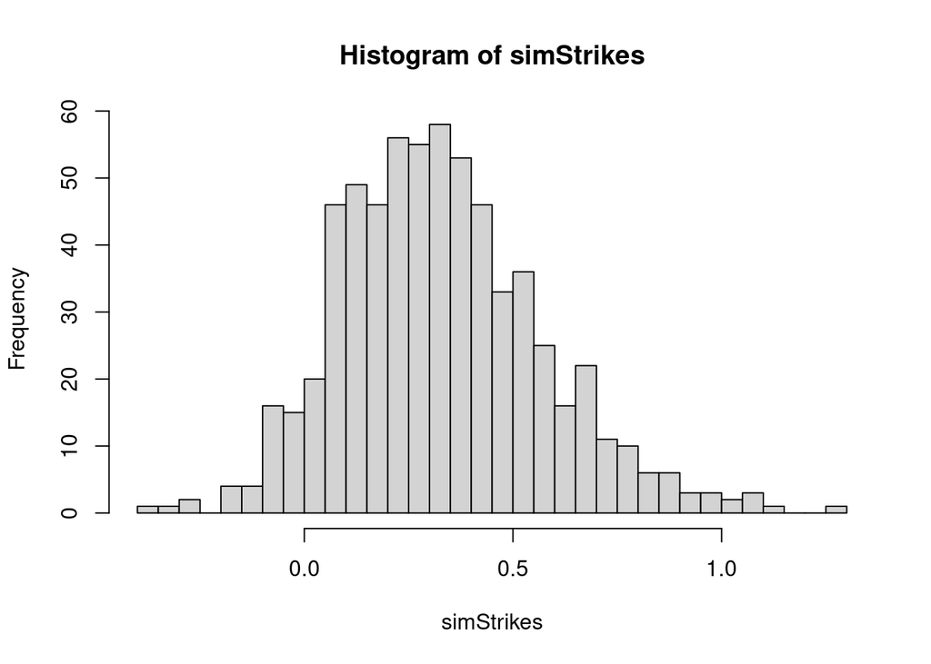

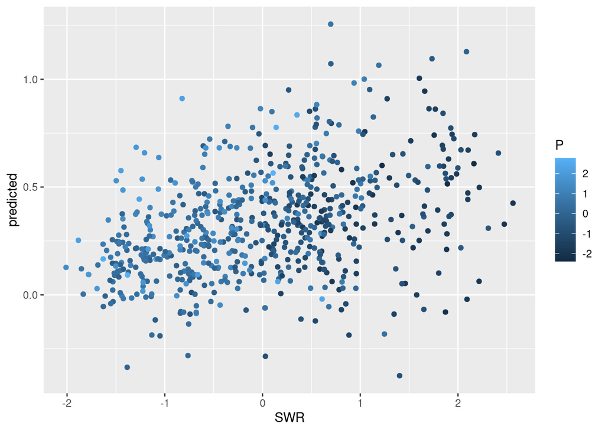

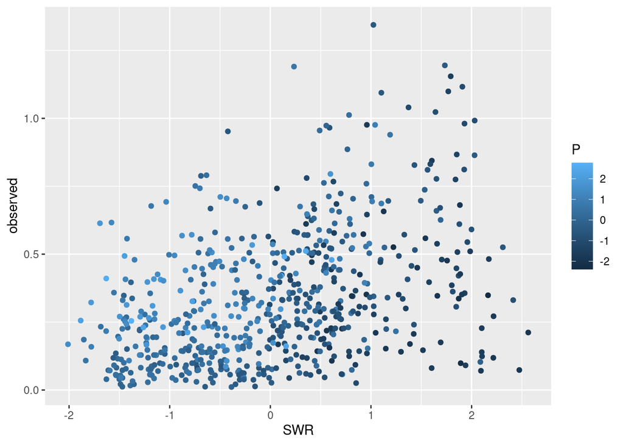

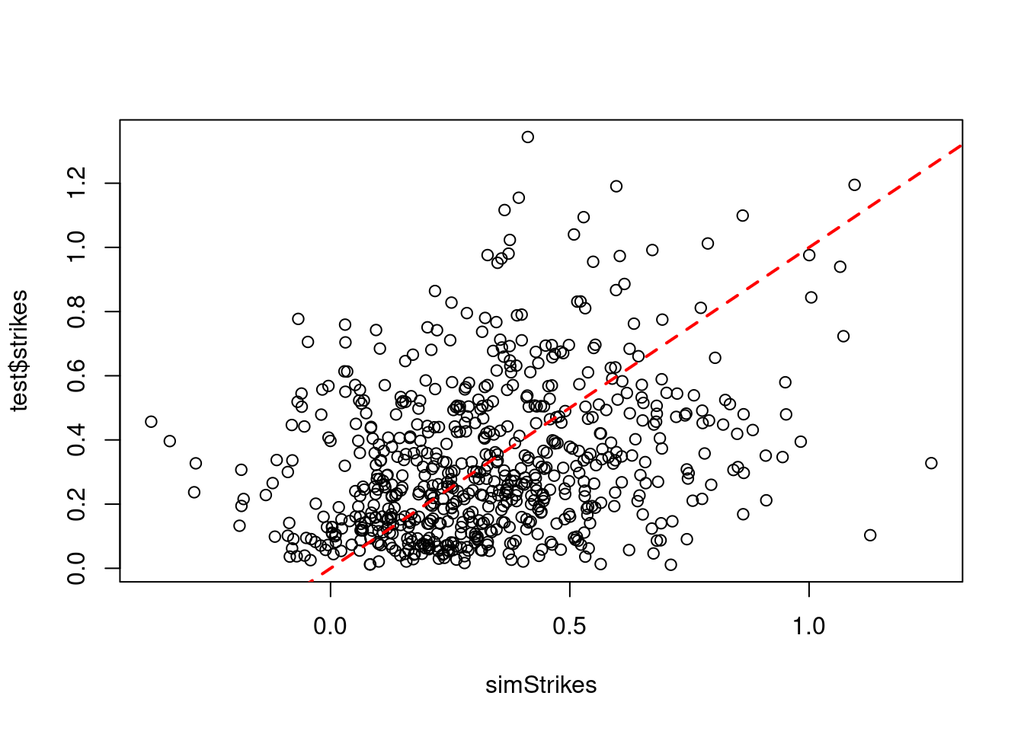

```r
compare(m0, m1, m2, m3, m4, m5, m6, m7, m8, m9, m10, m11, m12, m13, m14, m15, m16, m17)
```

```
##            WAIC        SE      dWAIC       dSE       pWAIC        weight
## m16 -1211.94593 122.12522    0.00000        NA   18.057774  1.000000e+00
## m14 -1112.13442 119.91578   99.81151  31.07357   20.357696  2.119365e-22
## m17  -978.71070 120.91432  233.23523  25.53283   65.967956  2.257429e-51
## m13  -898.43999 114.39352  313.50594  41.38198   18.519880  8.376274e-69
## m12  -846.41240 114.38725  365.53353  38.56659   14.843355  4.220869e-80
## m9   -830.04659 111.46020  381.89934  43.34074    9.901245  1.179267e-83
## m11  -827.95100 111.12105  383.99494  43.30101   11.140071  4.135798e-84
## m1   -827.84453 141.91971  384.10140 107.65053    8.459330  3.921388e-84
## m4   -602.46681 101.81864  609.47913  62.91460    6.178981 4.500798e-133
## m5   -434.10114 116.67258  777.84479  71.48702    5.757263 1.239224e-169
## m2   -423.02011 141.21362  788.92582 104.86813    9.699963 4.863343e-172
## m3   -301.63451 105.78752  910.31142  86.91373    6.122462 2.130031e-198
## m8    -89.76577 114.80973 1122.18016  94.23363    6.227969 2.097365e-244
## m7    134.42760  98.73916 1346.37353  88.66642    5.588096 4.352133e-293
## m10   187.40496 104.53551 1399.35089  86.55931    5.539990 1.364001e-304
## m6    195.97247 103.46842 1407.91840  88.77635    6.142250 1.881068e-306
## m0    204.89512 102.89074 1416.84105  88.24207    2.995628 2.172079e-308
## m15  3608.82534 249.99219 4820.77127 181.76645 1427.333891  0.000000e+00
```

M16 has the lowest WAIC score! This model excludes wind:

```
S ~ dnorm( mu , sigma )
mu = a_mu + b_mu*SWR + c_mu*T + d_mu*RH + f_mu*P + g_mu*SP
sigma = a_sigma + b_sigma*SWR + c_sigma*T + d_sigma*RH + f_sigma*P + g_sigma*SP
```